# 01.data_mining_glacier.Rmd

#### Homoscedasticité

Vérifier que la variance des erreurs est constante à travers les valeurs ajustées.

Test graphique : Graphique des résidus vs valeurs ajustées (Les résidus devraient être aléatoires, sans tendance claire, et distribués autour de zéro avec une variance constante)

Test statistique : Le test de Breusch-Pagan

```r
bptest(model)  # Test de Breusch-Pagan pour l'homoscedasticité
```

```
##
##  studentized Breusch-Pagan test
##
## data:  model
## BP = 4.9148, df = 7, p-value = 0.6704
```

#### Normalité des résidus

Vérifier que les résidus du modèle suivent une distribution normale. Test graphique : QQ-plot des résidus : Le QQ-plot compare les quantiles des résidus à ceux d’une distribution normale. Si les points suivent une droite, cela suggère que les résidus sont normalement distribués.

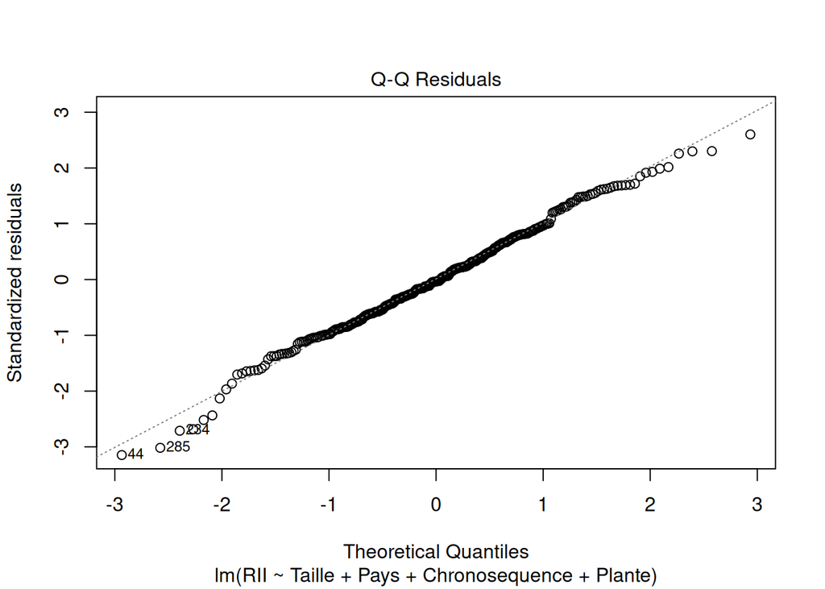

```r
# Tracer le QQ-plot des résidus
plot(model, which = 2)  # Graphique QQ-plot
```

Test statistique : Test de Shapiro-Wilk : Ce test évalue si les résidus suivent une distribution normale. Une p-value inférieure à 0.05 indique que les résidus ne suivent pas une distribution normale.

```r
# Test de normalité de Shapiro-Wilk
shapiro.test(residuals(model))
```

```
##
##  Shapiro-Wilk normality test
##
## data:  residuals(model)
## W = 0.99366, p-value = 0.2405
```

### Analyse de la sortie

```r
# Résumé du modèle
summary(model)
```

```
##
## Call:
## lm(formula = RII ~ Taille + Pays + Chronosequence + Plante, data = data_test)
##
## Residuals:
##     Min      1Q  Median      3Q     Max
## -3.3516 -0.7108 -0.0378  0.7363  2.7710
##
## Coefficients: (1 not defined because of singularities)
##                     Estimate Std. Error t value Pr(>|t|)
## (Intercept)         -0.56847    0.81560  -0.697    0.486
## Taille               0.61386    0.96244   0.638    0.524
## PaysFrance          -0.01651    0.15268  -0.108    0.914
## PaysPerou           -0.06420    0.15268  -0.421    0.674
## ChronosequenceVieux  0.14799    0.12466   1.187    0.236
## PlanteB             -0.14919    0.20561  -0.726    0.469
## PlanteC              0.10428    0.39412   0.265    0.792
## PlanteD             -0.19242    0.17480  -1.101    0.272
## PlanteE                   NA         NA      NA       NA
##
## Residual standard error: 1.08 on 292 degrees of freedom
## Multiple R-squared:  0.01067,    Adjusted R-squared:  -0.01305
## F-statistic:  0.45 on 7 and 292 DF,  p-value: 0.8699
```

Vérifier les coefficients : Interpréter les coefficients pour chaque variable (comment chaque facteur affecte RII).

Valeurs p : Vérifier les valeurs p pour déterminer si les variables explicatives sont significativement associées à la variable cible.

R² ajusté : Vérifier l’ajustement du modèle.

### Plot des effets

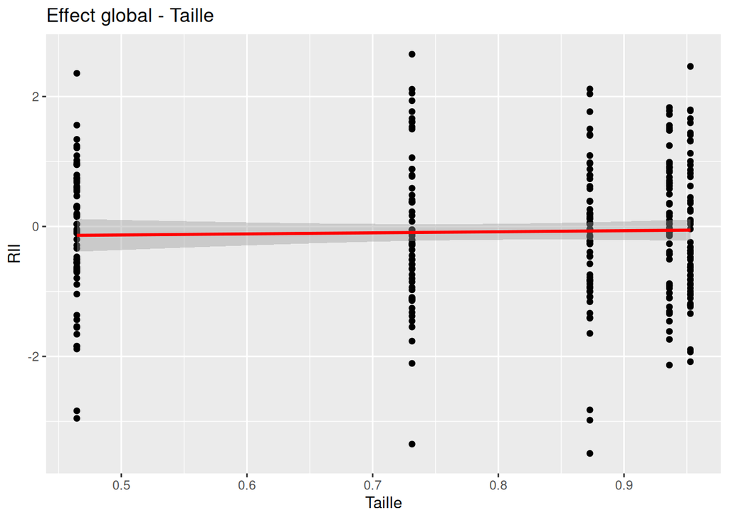

```r
# Variable : Taille

# Effet global
ggplot(data_test, aes(x = Taille, y = RII)) +
  geom_point() +
  geom_smooth(method = "lm", col = "red") +
  ggtitle("Effect global - Taille")
```

```r
# Effet marginal
effects <- ggpredict(model, terms = "Taille")  # Effet de x1
```

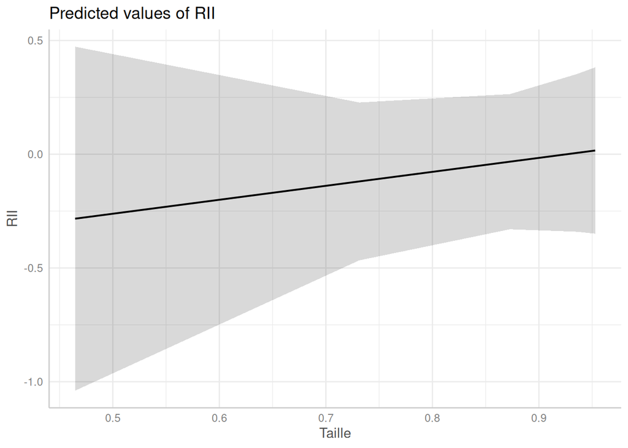

```r
plot(effects)
```

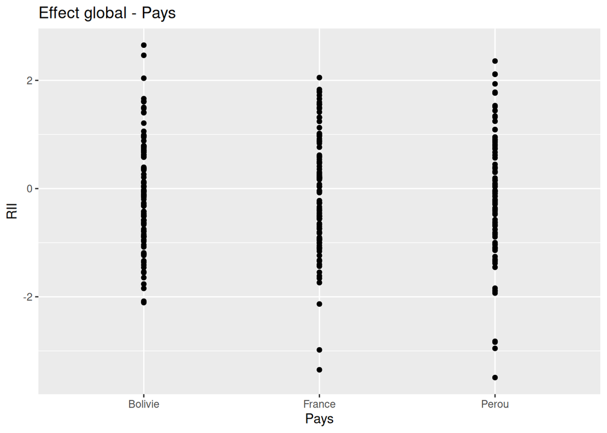

```r
# Variable : Pays

# Effet global
ggplot(data_test, aes(x = Pays, y = RII)) +
  geom_point() +
  geom_smooth(method = "lm", col = "red") +
  ggtitle("Effect global - Pays")
```

```r
# Effet marginal
effects <- ggpredict(model, terms = "Pays")  # Effet de x1
```

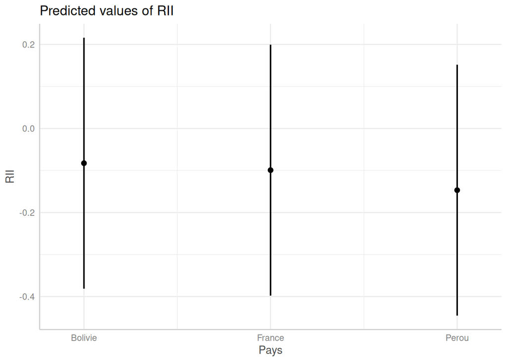

```r
plot(effects)
```